# DS152 Tutorial Sheet 4

## Exercise

The `barley` dataset contains data on an experiment set up in a completely randomised design with three replicates and two factors: `nutrient` (with three levels: nitrogen, phosphate and potassium) and `dose` (with three levels: 10ppm, 100ppm and 1000ppm), totaling nine treatments. The `yield` was measured in tonnes per hectare.

You can run the code below to glimpse the dataset:

```r
barley <- read_csv("https://www.dropbox.com/s/4p6ziofmxe2bqcf/barley.csv?raw=1")
glimpse(barley)
```

```
Rows: 27
Columns: 3
$ dose     <chr> "10ppm", "10ppm", "10ppm", "10ppm", "10ppm", "10ppm", "10ppm"…
$ nutrient <chr> "nitrogen", "nitrogen", "nitrogen", "phosphate", "phosphate",…
$ yield    <dbl> 3.727060, 4.268293, 4.209812, 4.708186, 5.423730, 5.133011, 6…
```

The table below displays means per each dose:nutrient combination:

```r
barley_summarise <- barley %>%
                      group_by(dose, nutrient) %>%
                      summarise(mean_yield = mean(yield) %>% round(2),
                                n = n())
barley_summarise
```

```
# A tibble: 9 × 4
# Groups:   dose [3]
  dose    nutrient  mean_yield     n
  <chr>   <chr>          <dbl> <int>
1 1000ppm nitrogen       10.2      3
2 1000ppm phosphate       7.57     3
3 1000ppm potassium       6.86     3
4 100ppm  nitrogen        6.88     3
5 100ppm  phosphate       7.69     3
6 100ppm  potassium       9.12     3
7 10ppm   nitrogen        4.07     3
8 10ppm   phosphate       5.09     3
9 10ppm   potassium       5.85     3
```

**(a)** Use `pivot_wider` on this table to have separate columns for the nitrogen, phosphate and potassium means per dose group as shown below:

```r
barley_summ_wide <- barley_summarise %>%
                      pivot_wider(names_from = "nutrient",
                                  values_from = "mean_yield")

barley_summ_wide
```

```
# A tibble: 3 × 5
# Groups:   dose [3]
  dose        n nitrogen phosphate potassium
  <chr>   <int>    <dbl>     <dbl>     <dbl>
1 1000ppm     3    10.2       7.57      6.86
2 100ppm      3     6.88      7.69      9.12
3 10ppm       3     4.07      5.09      5.85
```

**(b)** Which treatment (dose:nutrient combination) seems to be associated with the largest yield?

```r
barley_summarise %>%
  arrange(desc(mean_yield))
```

```
# A tibble: 9 × 4
# Groups:   dose [3]
  dose    nutrient  mean_yield     n
  <chr>   <chr>          <dbl> <int>
1 1000ppm nitrogen       10.2      3
2 100ppm  potassium       9.12     3
3 100ppm  phosphate       7.69     3
4 1000ppm phosphate       7.57     3
5 100ppm  nitrogen        6.88     3
6 1000ppm potassium       6.86     3
7 10ppm   potassium       5.85     3
8 10ppm   phosphate       5.09     3
9 10ppm   nitrogen        4.07     3
```

**(c)** Which dose seems to be associated with the largest yield?

```r
barley_summarise %>% group_by(dose) %>% summarise(mean(mean_yield))
```

```
# A tibble: 3 × 2
  dose    `mean(mean_yield)`
  <chr>                <dbl>
1 1000ppm               8.20
2 100ppm                7.90
3 10ppm                 5.00
```

```r
## which is the same as...
barley %>% group_by(dose) %>% summarise(mean(yield))
```

```
# A tibble: 3 × 2
  dose    `mean(yield)`
  <chr>           <dbl>
1 1000ppm          8.20
2 100ppm           7.90
3 10ppm            5.00
```

**(d)** Which nutrient seems to be associated with the largest yield?

```r
barley_summarise %>% group_by(nutrient) %>% summarise(mean(mean_yield))
```

```
# A tibble: 3 × 2
  nutrient  `mean(mean_yield)`
  <chr>                  <dbl>
1 nitrogen                7.04
2 phosphate               6.78
3 potassium               7.28
```

```r
## which is the same as...
barley %>% group_by(nutrient) %>% summarise(mean(yield))
```

```
# A tibble: 3 × 2
  nutrient  `mean(yield)`
  <chr>             <dbl>
1 nitrogen           7.04
2 phosphate          6.78
3 potassium          7.28
```

**(e)** The figure below displays an ‘interaction plot’, as seen in class. Does there appear to be an interaction between the factors `dose` and `nutrient`? Why?

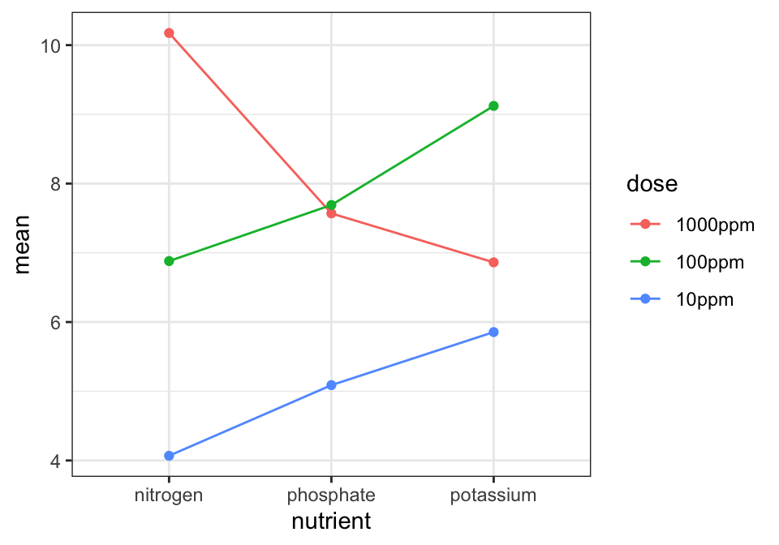

```r
barley %>%
  group_by(dose, nutrient) %>%
  summarise(mean = mean(yield)) %>%
  ggplot(aes(x = nutrient, y = mean, colour = dose, group = dose)) +
  theme_bw() +
  geom_point() +
  geom_line()
```